# 데이터 크리에이터를 위한 시각화 가이드

## 개요

"The Wall Street Journal Guide to Information Graphics" ( 월스트리트저널 인포그래픽 가이드 )

책을 참고해서, 독자들을 위한 **데이터 시각화의 기본적인 사항**을 알아보자.

[figure not shown]

```
                (기본의 중요성)
```

기본의 중요성을 체감하기 위해서

책을 읽기 전에 작성했던 기본적인 사항을 고려하지 않았을 때의 시각화 결과물과

책에서 배운 내용을 적용한 시각화 결과물을 비교해보자.

## 장식 목적이 아닌 정보전달을 위해 색을 사용하자

최근에 작성한 데이터스토리에서 드라마에 출연하는 배우의 나이와 시청률의 상관관계를 본적이 있다.

해당 그래프를 보여주면서 전달하고자 했던 점은 **연령대에 따른 시청률의 차이**였다.

[interactive chart not shown]

물론, 나는 색을 장식 목적으로 사용하지는 않았다.

다만, 색으로 서로 다른 드라마라는 것을 보여주고 싶었다.

하지만 위의 그래프를 봤을 때, 드라마의 수가 많아서 현란한 색으로 해당 목적이 잘 전달되지 않았을 수도 있겠다는 생각을 했다.

본래의 목적인 **연령대에 따른 시청률의 차이**를 더 잘 나타내기 위해 다음과 같이 바꿔 보았다.

[interactive chart not shown]

여러분은 어떤 그래프에서 연령대에 따른 시청률의 차이가 잘 느껴졌는가

사람마다 선호하는게 다를 수 있다.

하지만 책 "The Wall Street Journal Guide to Information Graphics" 에서는 말한다.

**"장식 목적이 아닌 정보전달을 위해 색을 사용해라"**

## 근본이되는 데이터를 압도하는 타이포그래피

### 공간 절약을 위해 글꼴을 회전시키지 마라

대한민국 군인마트 PX에서 어떤 상품이 잘 팔릴까?를 알아보는

데이터스토리에서 나온 그래프이다.

[interactive chart not shown]

위의 그래프를 보면 y축을 나타내는 텍스트가 세로로 적혀있는 것을 볼 수 있다.

책에서는 한눈에 정보를 받아들일 수 있게 글꼴을 회전시키지 말라고 말한다.

이제껏 자동으로 세로쓰기가 설정되어 왔기 때문에 그냥 썼지만...

독자 friendly한 그래프를 그리고 싶기에 바꿔보려한다.

하지만 plotly 라이브러리에는 y축의 텍스트를 90도 회전할 수 있는 옵션이 없다..

그래서 matplotlib 라이브러리를 사용해서 비교해 보았다.

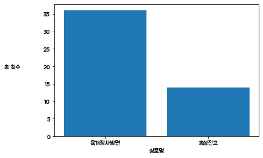

어떤 그래프가 더 직관적인가?

개인적으로 matplotlib 라이브러리가 더 직관적으로 보인다.

( matplotlib으로 갈아타야하는 것일까? )

이번에는 x축의 텍스트가 회전되어있는 경우이다.

해당 그래프는 송중기 배우의 출연작 시청률을 나타내는 그래프다.

이 경우에는 드라마의 이름이 길어서 대각선으로 텍스트가 배치되어있다.

[interactive chart not shown]

책에서 **이름이 긴 경우에는 대안으로써 수평 막대 차트로 표현한다**.

라고 말한다.

책에서 시킨대로 해봤다.

[interactive chart not shown]

확실히 한눈에 더 들어오는것 같다.

지금까지 '공간 절약을 위해 글꼴을 회전시키지 마라'라는 책의 조언에 따라 그래프를 개선 시켜봤다.

확실히 글꼴의 거추장스러움의 제거하니 한눈에 정보가 전달되는 듯한 느낌을 받았다.

**데이터를 압도하는 텍스트의 시각적 효과를 지양하자**!

## 차트 하나에 선은 네 개 이하

'차트 하나에 표현할 선은 3개까지로 제한하며, 교차지점이 많지 않으면 최대 4개까지도 가능하다.'

'PX에서 여름에 어떤 음료가 많이 팔릴까'라는 데이터스토리를 작성할 때

다양한 종류의 음료수 누적 판매 개수를 나타내기 위해 아래와 같은 차트를 그린 적이있다.

[interactive chart not shown]

한눈에 보기에 너무 지저분하다는 생각이 들었지만, 다른 방법이 떠오르지 않았다.

차트 선의 개수를 4개 이하로 줄여보면 어떨까?

[interactive chart not shown]

이것도 그다지 좋아보이지 않는다.

애초에 추세선 그래프는 이 데이터에 어울리지 않았던 것일까?

이 데이터를 더 효과적으로 잘 나타낼 방법은 더 고민해봐야 할 것같다.

( 책에서는 다른 방법으로 데이터 집합이 4개 이상이면, 개개의 선을 하나씩 따로 빼내서 배열하는 방법을 추천하기도 한다. )

## 결론

"The Wall Street Journal Guide to Information Graphics"

책을 읽고 쉽게 지나칠 수 있었던 사항들에 대해서

더 세심한 신경을 써야겠다는 생각이 들었다.

더 **명확**하고 **직관**적인 데이터 시각화를 위해서!